# Analysis of Attrition of Employees for Company Dataset

### By Peter Apazidis and Mohammed Kabir

This project is based on a dataset from Kaggle representing different attributes about the relationship between employees and a certain company (the company name was not given). The task given by the person who supplied the dataset is to find out why many of the employees at their company are leaving. Supposedly, there are a few attributes that might be a major part of the reason for the growing amount of departures from the company. Link to the dataset: https://www.kaggle.com/patelprashant/employee-attrition

```python
import pandas as pd # to store our dataset as a DataFrame and manipulate it
import numpy as np
import seaborn as sns # for data exploration
import matplotlib.pyplot as plt # to modify our seaborn visuals
from sklearn.linear_model import LinearRegression
from sklearn.model_selection import train_test_split
```

```python
df = pd.read_csv("employee_data.csv") # read the .csv into df

mdf = df.copy(deep=True) #dataframe used for machine learning portion of project
df.head() # displays the first few rows of the dataset
```

|  | Age | Attrition | BusinessTravel | DailyRate | Department | DistanceFromHome | Education | EducationField | EmployeeCount | EmployeeNumber | EnvironmentSatisfaction | Gender | HourlyRate | JobInvolvement | JobLevel | JobRole | JobSatisfaction | MaritalStatus | MonthlyIncome | MonthlyRate | NumCompaniesWorked | Over18 | OverTime | PercentSalaryHike | PerformanceRating | RelationshipSatisfaction | StandardHours | StockOptionLevel | TotalWorkingYears | … |
| --- | --- | --- | --- | --- | --- | --- | --- | --- | --- | --- | --- | --- | --- | --- | --- | --- | --- | --- | --- | --- | --- | --- | --- | --- | --- | --- | --- | --- | --- | --- |
| 0 | 41 | Yes | Travel_Rarely | 1102 | Sales | 1 | 2 | Life Sciences | 1 | 1 | 2 | Female | 94 | 3 | 2 | Sales Executive | 4 | Single | 5993 | 19479 | 8 | Y | Yes | 11 | 3 | 1 | 80 | 0 | 8 | … |
| 1 | 49 | No | Travel_Frequently | 279 | Research & Development | 8 | 1 | Life Sciences | 1 | 2 | 3 | Male | 61 | 2 | 2 | Research Scientist | 2 | Married | 5130 | 24907 | 1 | Y | No | 23 | 4 | 4 | 80 | 1 | 10 | … |
| 2 | 37 | Yes | Travel_Rarely | 1373 | Research & Development | 2 | 2 | Other | 1 | 4 | 4 | Male | 92 | 2 | 1 | Laboratory Technician | 3 | Single | 2090 | 2396 | 6 | Y | Yes | 15 | 3 | 2 | 80 | 0 | 7 | … |
| 3 | 33 | No | Travel_Frequently | 1392 | Research & Development | 3 | 4 | Life Sciences | 1 | 5 | 4 | Female | 56 | 3 | 1 | Research Scientist | 3 | Married | 2909 | 23159 | 1 | Y | Yes | 11 | 3 | 3 | 80 | 0 | 8 | … |
| 4 | 27 | No | Travel_Rarely | 591 | Research & Development | 2 | 1 | Medical | 1 | 7 | 1 | Male | 40 | 3 | 1 | Laboratory Technician | 2 | Married | 3468 | 16632 | 9 | Y | No | 12 | 3 | 4 | 80 | 1 | 6 | … |

```python
df.shape
```

```
(1470, 35)
```

## Tidying the Data

We do not need the "Over18", "StandardHours", and "EmployeeCount" columns because all of the entries in these rows are the same values. That matters because if all entries are the same, whether an employee leaves or stays at the company wont be affected at all by a variable that never changes regardless. The "DailyRate" column is dropped because it can be derived from the "HourlyRate" attribute, so its data is redundant. "EmployeeNumber" contains only unique entries that simply identify employees, which is not relevant to the problem of finding out the reason behind attrition.

```python
df.drop(columns=["Over18","StandardHours","EmployeeCount", "DailyRate", "EmployeeNumber"], inplace=True)
```

```python
df.rename(columns = {"Attrition": "Label"}, inplace=True)
cols = list(df)
cols[1], cols[0] = cols[0], cols[1]
df_swp = df.reindex(columns=cols) #we want "dont leave" to be 0 and "leave" to 1
```

We want to encode attribues whose entries consist of words. This is because it will enable the machine learning model to train on categorical attributes. Most of the encodings for these attributes had to be made arbitrarily since there is no correct way to encode them. However, for binary attributes we encoded them as 0s and 1s, where 0s represented the negation of something while 1s represented the positives.

```python
categories_encoded = {
    "Attrition": {"No":0, "Yes": 1},
    "BusinessTravel": {"Non-Travel": 0, "Travel_Rarely":1, "Travel_Frequently":2},
    "Department": {"Sales":0, "Research & Development":1, "Human Resources": 2},
    "EducationField": {"Life Sciences":0, "Medical":1, "Marketing":2, "Technical Degree":3, "Human Resources":4, "Other":5},
    "Gender": {"Male":0, "Female":1},
    "JobRole": {"Sales Executive":0, "Research Scientist":1, "Laboratory Technician":2, "Manufacturing Director":3, "Healthcare Representative":4, "Healthcare Representative":5, "Manager":6, "Sales Representative":7, "Research Director":8, "Human Resources":9},
    "MaritalStatus": {"Divorced":0, "Single":1, "Married":2},
    "Label": {"No":0, "Yes":1},
    "OverTime": {"No":0, "Yes": 1}
}
```

```python
df_enc = df.replace(categories_encoded)
df_enc.head()
```

|  | Age | Label | BusinessTravel | Department | DistanceFromHome | Education | EducationField | EnvironmentSatisfaction | Gender | HourlyRate | JobInvolvement | JobLevel | JobRole | JobSatisfaction | MaritalStatus | MonthlyIncome | MonthlyRate | NumCompaniesWorked | OverTime | PercentSalaryHike | PerformanceRating | RelationshipSatisfaction | StockOptionLevel | TotalWorkingYears | TrainingTimesLastYear | WorkLifeBalance | YearsAtCompany | YearsInCurrentRole | YearsSinceLastPromotion | … |
| --- | --- | --- | --- | --- | --- | --- | --- | --- | --- | --- | --- | --- | --- | --- | --- | --- | --- | --- | --- | --- | --- | --- | --- | --- | --- | --- | --- | --- | --- | --- |
| 0 | 41 | 1 | 1 | 0 | 1 | 2 | 0 | 2 | 1 | 94 | 3 | 2 | 0 | 4 | 1 | 5993 | 19479 | 8 | 1 | 11 | 3 | 1 | 0 | 8 | 0 | 1 | 6 | 4 | 0 | … |
| 1 | 49 | 0 | 2 | 1 | 8 | 1 | 0 | 3 | 0 | 61 | 2 | 2 | 1 | 2 | 2 | 5130 | 24907 | 1 | 0 | 23 | 4 | 4 | 1 | 10 | 3 | 3 | 10 | 7 | 1 | … |
| 2 | 37 | 1 | 1 | 1 | 2 | 2 | 5 | 4 | 0 | 92 | 2 | 1 | 2 | 3 | 1 | 2090 | 2396 | 6 | 1 | 15 | 3 | 2 | 0 | 7 | 3 | 3 | 0 | 0 | 0 | … |
| 3 | 33 | 0 | 2 | 1 | 3 | 4 | 0 | 4 | 1 | 56 | 3 | 1 | 1 | 3 | 2 | 2909 | 23159 | 1 | 1 | 11 | 3 | 3 | 0 | 8 | 3 | 3 | 8 | 7 | 3 | … |
| 4 | 27 | 0 | 1 | 1 | 2 | 1 | 1 | 1 | 0 | 40 | 3 | 1 | 2 | 2 | 2 | 3468 | 16632 | 9 | 0 | 12 | 3 | 4 | 1 | 6 | 3 | 3 | 2 | 2 | 2 | … |

Here is a plot representing the total count of those who left the company and those that stayed. The 0 on the x-axis represents those that stayed and 1 represents those that left. Obviously there are a lot more employees that stayed than that left since attrition is defined by a gradual decline in the size of the workforce of a company.

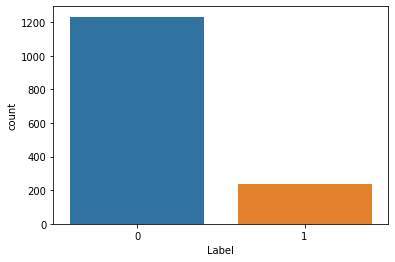

```python
#@title
sns.countplot(df_enc["Label"])
```

## Exploratory Data Analysis and Visualizations

Now that we have tidied up the dataset and encoded whatever attributes we needed, it is time to analyze the data and find trends. A good start to doing this is creating a heatmap of correlations between each of the attributes against each other. This way, we get a very broad overview of the relationships between different attributes, which can be used to quickly find certain trends.

The heatmap below is based on Pearson's coefficient, where the range of values for each entry is between -100% and 100% inclusive, indicating how negatively or positively correlated attributes are respectively. A value of 0% would indicate no correlation.

If there are any attributes that have strong negative or positive correlations, then it could indicate redundancy in the dataset. There happens to be such a type of correlation between "MonthlyIncome" and "JobLevel", which makes sense since the more presegious jobs typically come with a higher paying salary. One of these attributes will have to be deleted because highly correlated attributes tend to introduce bias into machine learning models.

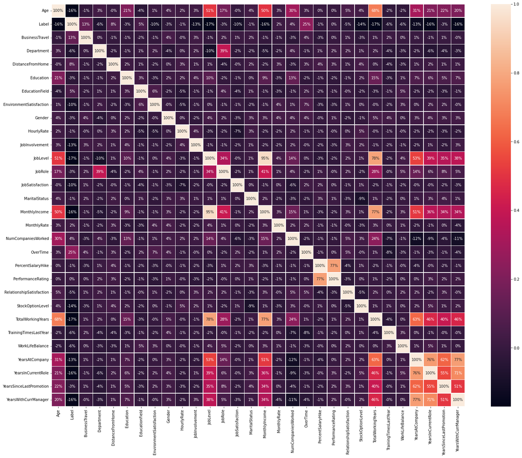

```python
plt.subplots(figsize=(25, 20))
sns.heatmap(df_enc.corr('pearson'), annot = True, linewidths=0.5, fmt='.00%')
```

```python
#dropping the JobLevel column because it correlates too heavily with MonthlyIncome
df_enc.drop(columns=["JobLevel"], inplace=True)
```

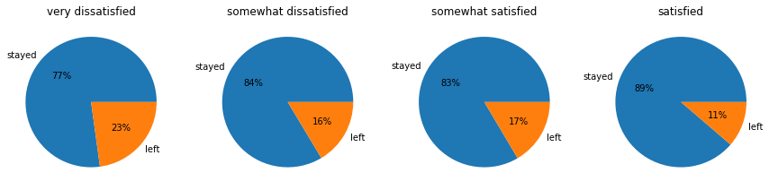

```python
plt.figure(figsize=(15,20))
job_sat_li = df_enc['JobSatisfaction'].unique()
job_sat_li.sort()
sat_labels = ['very dissatisfied', 'somewhat dissatisfied', 'somewhat satisfied', 'satisfied']
for i, level in enumerate(job_sat_li):
  attrition_vals = df_enc[df_enc['JobSatisfaction'] == level]['Label']
  attrition_cnts_dic = attrition_vals.value_counts().to_dict()
  # print(attrition_vals.value_counts().to_dict())
  plt.subplot(1, 4, i+1)
  plt.title(sat_labels[i])
  plt.pie([attrition_cnts_dic[0], attrition_cnts_dic[1]], labels=['stayed','left'], autopct='%0.0f%%')
```

According to the correlation heatmap, there is a relatively significant correlation between "TotalWorkingYears" (the number of years an employee worked at a company) and attrition. From the pie charts below it can be seen that this correlation holds true, but more so at the extreme data points. That is, there is a small difference between the attrition of employees that have worked between 5-19 years, but there is a huge difference between those who had worked 0-4 years and those who worked more than 19 years.

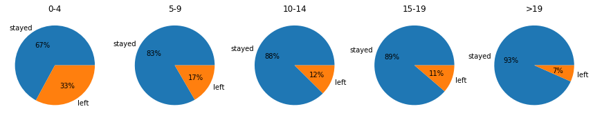

```python
plt.figure(figsize=(15,20))
range_starts = [-1,4,9,14,19,20]
overtime_labels = ['0-4', '5-9', '10-14', '15-19', '>19']
for i, level in enumerate(overtime_labels):
  if i == 5:
    attrition_vals = df_enc[df_enc['TotalWorkingYears'] >= range_starts[i]]['Label']
  else:
    attrition_vals = df_enc[(df_enc['TotalWorkingYears'] > range_starts[i]) & (df_enc['TotalWorkingYears'] <= range_starts[i+1])]['Label']
  attrition_cnts_dic = attrition_vals.value_counts().to_dict()
  # print(attrition_vals.value_counts().to_dict())
  plt.subplot(1, 5, i+1)
  plt.title(overtime_labels[i])
  plt.pie([attrition_cnts_dic[0], attrition_cnts_dic[1]], labels=['stayed','left'], autopct='%0.0f%%')
# plt.scatter(df_enc['TotalWorkingYears'])
```

The ranges of the bins for the pie charts above were set somewhat arbitrarily. Within each range there could be a subset of data that skews the result of the pie graph. For example, in the 5-9 range of TotalWorkingYears, those who worked 5-6 years may have a much higher attrition rate than those who worked 7-9 years. Thus, we want to play around with adjusting the ranges to see if we can get more specific information about employees who worked a certain range of years. The 0-4 range seems to be yielding some interesting data, so we will start by dividing that range into smaller ranges.

After dividing the 0-4 range into smaller bins, we find that we were right in guessing that our data was skewed. Almost exactly half of all employees that worked less than 1 year left the company, while only about 20% left of those who worked 4-5 years. Using this information, we can narrow our analysis of attrition down to finding how employees who worked less than 1 year correlates with other attributes in the dataset.

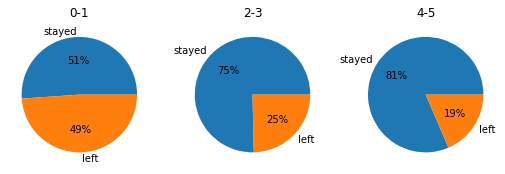

```python
plt.figure(figsize=(15,20))
range_starts = [-1,1,3,5]
overtime_labels = ['0-1', '2-3', '4-5']
for i, level in enumerate(overtime_labels):
  if i == 3:
    break;
  else:
    attrition_vals = df_enc[(df_enc['TotalWorkingYears'] > range_starts[i]) & (df_enc['TotalWorkingYears'] <= range_starts[i+1])]['Label']
  attrition_cnts_dic = attrition_vals.value_counts().to_dict()
  plt.subplot(1, 5, i+1)
  plt.title(overtime_labels[i])
  plt.pie([attrition_cnts_dic[0], attrition_cnts_dic[1]], labels=['stayed','left'], autopct='%0.0f%%')
```

Looking back at the correlation heatmap, it can be seen that the attributes "TotalWorkingYears" and "MonthlyIncome" have a relatively high correlation between each other. To better visualize the relationship between these two attributes we created a scatter plot with a best fit line. The strong positive slope of the line indicates that as the TotalWorkingYears of the employees increases, so does their pay. Given that employees of companies are generally driven by the amount of money they are paid, it is a reasonable hypothesis that employees who just started in this company are unhappy with the amount of income they receive.

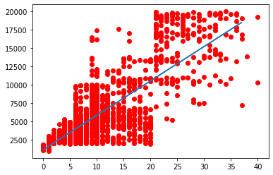

```python
x_train, x_test, year_train, year_test = train_test_split(df_enc['TotalWorkingYears'], df_enc['MonthlyIncome'])
LR = LinearRegression()
LR.fit(x_train.values.reshape(-1,1), year_train.values)
pred = LR.predict(x_test.values.reshape(-1,1))

plt.plot(x_test, pred)
plt.scatter(df_enc['TotalWorkingYears'], df_enc['MonthlyIncome'], c=['red'])
```

Another attribute that had a high correlation with "TotalWorkingYears" was "JobRole". "JobRole" has been encoded from words to numbers in order for our model to process the data for it.

Another attribute that had a high correlation with "TotalWorkingYears" was "JobRole". "JobRole" has been encoded from words to numbers in order for our model to process the data for it. The below graph again only looks at the "TotalWorkingYears" divided into 3 bins: employees with less than or equal to 1 year of work, employees with 2-3 years of work, and employees with 4-5 years of work. One notable characteristic of the below charts is that between charts 0-1 and 1-2 there is a 13% decrease in the number of Laboratory Technicians. The number only slightly drops again between the 2-3 and 4-5 chart by 2%.

From this it can be seen that the probability that employees who have only worked 1 year or less leave due in part to the fact that they held jobs as Laboratory Technicians. A possible reason as to why a decent chunk of Laboratory Technicians stay may be because as they work longer, they get paid more, a trend that we have seen before in the correlation matrix.

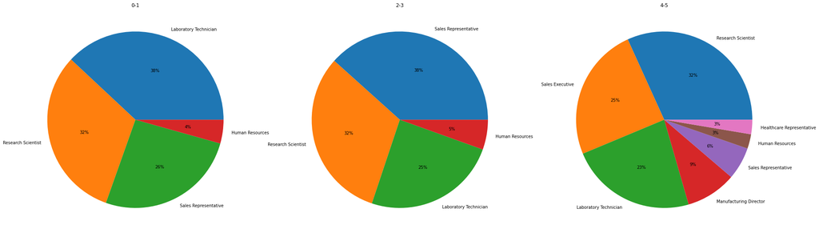

```python
def get_label(role_num):
  for role in categories_encoded["JobRole"]:
    if categories_encoded["JobRole"][role] == role_num:
      return role


plt.figure(figsize=(55,30))
range_starts = [-1,1,3,5]
overtime_labels = ['0-1', '2-3', '4-5']
for i, level in enumerate(overtime_labels):
  if i == 3:
    break;
  else:
    attrition_vals = df_enc[(df_enc['TotalWorkingYears'] > range_starts[i]) & (df_enc['TotalWorkingYears'] <= range_starts[i+1])]['JobRole']
  role_dic = attrition_vals.value_counts().to_dict()
  plt.subplot(1, 5, i+1)
  plt.title(overtime_labels[i])
  outputli = []
  lbls = []
  for role in role_dic:
    outputli.append(role_dic[role])
    lbls.append(get_label(role))
  plt.pie(outputli, labels=lbls, autopct='%0.0f%%')
```

According to the correlation heatmap, "OverTime" (employees who have worked overtime) is the most correlated attribute with attrition. As shown by the pie charts, a significantly greater amount of employees left the company when they had worked overtime, versus those who didn't. More specifically, it was a difference of 21%. In our learning models we are likely to see OverTime as the most influential factor of attrition at the company because of this. It is exepected that other attributes who had high correlations with attrition in the correlation matrix will be significant contributors as well.

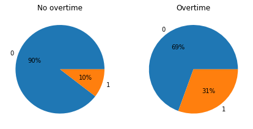

```python
plt.figure(figsize=(15,20))
job_sat_li = df_enc['OverTime'].unique()
job_sat_li.sort()
overtime_labels = ['No overtime', 'Overtime']
for i, level in enumerate(job_sat_li):
  attrition_vals = df_enc[df_enc['OverTime'] == level]['Label']
  attrition_cnts_dic = attrition_vals.value_counts().to_dict()
  # print(attrition_vals.value_counts().to_dict())
  plt.subplot(1, 4, i+1)
  plt.title(overtime_labels[i])
  plt.pie([attrition_cnts_dic[0], attrition_cnts_dic[1]], labels=[0,1], autopct='%0.0f%%')
```

## Let's Train Some Models

In the analysis, hypothesis testing, and ML phase we are going to see if we can learn a way to predict attrition. Since the prediction is just going to consist of whether the employee leaves the company or not, this is clearly a classificatin problem. We want to train some model to classify whether a given employee is likely to leave the company or stay based on the data we have about the employee.

For the previously mentioned reasons, we will drop the following columns from the dataframe.

```python
mdf = pd.read_csv("employee_data.csv") # read the .csv into df
mdf.drop(columns=["Over18","StandardHours","EmployeeCount", "DailyRate", "EmployeeNumber", 'JobLevel'], inplace=True)
mdf.head()
```

|  | Age | Attrition | BusinessTravel | Department | DistanceFromHome | Education | EducationField | EnvironmentSatisfaction | Gender | HourlyRate | JobInvolvement | JobRole | JobSatisfaction | MaritalStatus | MonthlyIncome | MonthlyRate | NumCompaniesWorked | OverTime | PercentSalaryHike | PerformanceRating | RelationshipSatisfaction | StockOptionLevel | TotalWorkingYears | TrainingTimesLastYear | WorkLifeBalance | YearsAtCompany | YearsInCurrentRole | YearsSinceLastPromotion | YearsWithCurrManager |
| --- | --- | --- | --- | --- | --- | --- | --- | --- | --- | --- | --- | --- | --- | --- | --- | --- | --- | --- | --- | --- | --- | --- | --- | --- | --- | --- | --- | --- | --- |
| 0 | 41 | Yes | Travel_Rarely | Sales | 1 | 2 | Life Sciences | 2 | Female | 94 | 3 | Sales Executive | 4 | Single | 5993 | 19479 | 8 | Yes | 11 | 3 | 1 | 0 | 8 | 0 | 1 | 6 | 4 | 0 | 5 |
| 1 | 49 | No | Travel_Frequently | Research & Development | 8 | 1 | Life Sciences | 3 | Male | 61 | 2 | Research Scientist | 2 | Married | 5130 | 24907 | 1 | No | 23 | 4 | 4 | 1 | 10 | 3 | 3 | 10 | 7 | 1 | 7 |
| 2 | 37 | Yes | Travel_Rarely | Research & Development | 2 | 2 | Other | 4 | Male | 92 | 2 | Laboratory Technician | 3 | Single | 2090 | 2396 | 6 | Yes | 15 | 3 | 2 | 0 | 7 | 3 | 3 | 0 | 0 | 0 | 0 |
| 3 | 33 | No | Travel_Frequently | Research & Development | 3 | 4 | Life Sciences | 4 | Female | 56 | 3 | Research Scientist | 3 | Married | 2909 | 23159 | 1 | Yes | 11 | 3 | 3 | 0 | 8 | 3 | 3 | 8 | 7 | 3 | 0 |
| 4 | 27 | No | Travel_Rarely | Research & Development | 2 | 1 | Medical | 1 | Male | 40 | 3 | Laboratory Technician | 2 | Married | 3468 | 16632 | 9 | No | 12 | 3 | 4 | 1 | 6 | 3 | 3 | 2 | 2 | 2 | 2 |

We will swap the order of the 'Attrition' and 'Age' columns.

```python
cols = list(mdf)
cols[1], cols[0] = cols[0], cols[1]
cols
mdf = mdf.reindex(columns=cols)
mdf.head()
```

|  | Attrition | Age | BusinessTravel | Department | DistanceFromHome | Education | EducationField | EnvironmentSatisfaction | Gender | HourlyRate | JobInvolvement | JobRole | JobSatisfaction | MaritalStatus | MonthlyIncome | MonthlyRate | NumCompaniesWorked | OverTime | PercentSalaryHike | PerformanceRating | RelationshipSatisfaction | StockOptionLevel | TotalWorkingYears | TrainingTimesLastYear | WorkLifeBalance | YearsAtCompany | YearsInCurrentRole | YearsSinceLastPromotion | YearsWithCurrManager |
| --- | --- | --- | --- | --- | --- | --- | --- | --- | --- | --- | --- | --- | --- | --- | --- | --- | --- | --- | --- | --- | --- | --- | --- | --- | --- | --- | --- | --- | --- |
| 0 | Yes | 41 | Travel_Rarely | Sales | 1 | 2 | Life Sciences | 2 | Female | 94 | 3 | Sales Executive | 4 | Single | 5993 | 19479 | 8 | Yes | 11 | 3 | 1 | 0 | 8 | 0 | 1 | 6 | 4 | 0 | 5 |
| 1 | No | 49 | Travel_Frequently | Research & Development | 8 | 1 | Life Sciences | 3 | Male | 61 | 2 | Research Scientist | 2 | Married | 5130 | 24907 | 1 | No | 23 | 4 | 4 | 1 | 10 | 3 | 3 | 10 | 7 | 1 | 7 |
| 2 | Yes | 37 | Travel_Rarely | Research & Development | 2 | 2 | Other | 4 | Male | 92 | 2 | Laboratory Technician | 3 | Single | 2090 | 2396 | 6 | Yes | 15 | 3 | 2 | 0 | 7 | 3 | 3 | 0 | 0 | 0 | 0 |
| 3 | No | 33 | Travel_Frequently | Research & Development | 3 | 4 | Life Sciences | 4 | Female | 56 | 3 | Research Scientist | 3 | Married | 2909 | 23159 | 1 | Yes | 11 | 3 | 3 | 0 | 8 | 3 | 3 | 8 | 7 | 3 | 0 |
| 4 | No | 27 | Travel_Rarely | Research & Development | 2 | 1 | Medical | 1 | Male | 40 | 3 | Laboratory Technician | 2 | Married | 3468 | 16632 | 9 | No | 12 | 3 | 4 | 1 | 6 | 3 | 3 | 2 | 2 | 2 | 2 |

Let's look at the datatypes in our dataframe.

```python
mdf.dtypes
```

```
Attrition                   object
Age                          int64
BusinessTravel              object
Department                  object
DistanceFromHome             int64
Education                    int64
EducationField              object
EnvironmentSatisfaction      int64
Gender                      object
HourlyRate                   int64
JobInvolvement               int64
JobRole                     object
JobSatisfaction              int64
MaritalStatus               object
MonthlyIncome                int64
MonthlyRate                  int64
NumCompaniesWorked           int64
OverTime                    object
PercentSalaryHike            int64
PerformanceRating            int64
RelationshipSatisfaction     int64
StockOptionLevel             int64
TotalWorkingYears            int64
TrainingTimesLastYear        int64
WorkLifeBalance              int64
YearsAtCompany               int64
YearsInCurrentRole           int64
YearsSinceLastPromotion      int64
YearsWithCurrManager         int64
dtype: object
```

Notice that the following attributes are non-numerical:

```python
mdf.select_dtypes(exclude=['number']).head()
```

|  | Attrition | BusinessTravel | Department | EducationField | Gender | JobRole | MaritalStatus | OverTime |
| --- | --- | --- | --- | --- | --- | --- | --- | --- |
| 0 | Yes | Travel_Rarely | Sales | Life Sciences | Female | Sales Executive | Single | Yes |
| 1 | No | Travel_Frequently | Research & Development | Life Sciences | Male | Research Scientist | Married | No |
| 2 | Yes | Travel_Rarely | Research & Development | Other | Male | Laboratory Technician | Single | Yes |
| 3 | No | Travel_Frequently | Research & Development | Life Sciences | Female | Research Scientist | Married | Yes |
| 4 | No | Travel_Rarely | Research & Development | Medical | Male | Laboratory Technician | Married | No |

The classication models we will use only work with numerical data. So we have to handle the non-numerical columns in some way. Since we cannot remove all of them we have a way to convert/encode them in a way that does not introduce bias into our data. Department, Education Field, Gender, JobRole, MaritalStatus, and OverTime are all categorical data while BusinessTravel is ordinal data.

Handling ordinal data is easy. We can just assign a unique number to each value, in a way that represents their natural order.

The Attrition attribute is going to be our y-label so we will also assign 1 to the 'Yes' value and 0 to the 'No' value.

```python
# We represent 'encoding' as a dictionary where the keys are the attribute names
# and the values are dictionaries where the keys are the non-numerical values and the values are the numerical assignments.
category_encoding = {
    "Attrition": {"No":0, "Yes": 1}, #y-label
    "BusinessTravel": {"Non-Travel": 0, "Travel_Rarely":1, "Travel_Frequently":2} #Ordinal Data
}
```

```python
mdf.replace(category_encoding, inplace=True) # we replace the columns with the new encodings.
mdf.head()
```

|  | Attrition | Age | BusinessTravel | Department | DistanceFromHome | Education | EducationField | EnvironmentSatisfaction | Gender | HourlyRate | JobInvolvement | JobRole | JobSatisfaction | MaritalStatus | MonthlyIncome | MonthlyRate | NumCompaniesWorked | OverTime | PercentSalaryHike | PerformanceRating | RelationshipSatisfaction | StockOptionLevel | TotalWorkingYears | TrainingTimesLastYear | WorkLifeBalance | YearsAtCompany | YearsInCurrentRole | YearsSinceLastPromotion | YearsWithCurrManager |
| --- | --- | --- | --- | --- | --- | --- | --- | --- | --- | --- | --- | --- | --- | --- | --- | --- | --- | --- | --- | --- | --- | --- | --- | --- | --- | --- | --- | --- | --- |
| 0 | 1 | 41 | 1 | Sales | 1 | 2 | Life Sciences | 2 | Female | 94 | 3 | Sales Executive | 4 | Single | 5993 | 19479 | 8 | Yes | 11 | 3 | 1 | 0 | 8 | 0 | 1 | 6 | 4 | 0 | 5 |
| 1 | 0 | 49 | 2 | Research & Development | 8 | 1 | Life Sciences | 3 | Male | 61 | 2 | Research Scientist | 2 | Married | 5130 | 24907 | 1 | No | 23 | 4 | 4 | 1 | 10 | 3 | 3 | 10 | 7 | 1 | 7 |
| 2 | 1 | 37 | 1 | Research & Development | 2 | 2 | Other | 4 | Male | 92 | 2 | Laboratory Technician | 3 | Single | 2090 | 2396 | 6 | Yes | 15 | 3 | 2 | 0 | 7 | 3 | 3 | 0 | 0 | 0 | 0 |
| 3 | 0 | 33 | 2 | Research & Development | 3 | 4 | Life Sciences | 4 | Female | 56 | 3 | Research Scientist | 3 | Married | 2909 | 23159 | 1 | Yes | 11 | 3 | 3 | 0 | 8 | 3 | 3 | 8 | 7 | 3 | 0 |
| 4 | 0 | 27 | 1 | Research & Development | 2 | 1 | Medical | 1 | Male | 40 | 3 | Laboratory Technician | 2 | Married | 3468 | 16632 | 9 | No | 12 | 3 | 4 | 1 | 6 | 3 | 3 | 2 | 2 | 2 | 2 |

Let's split our dataframe into the sample and label.

```python
data = mdf.iloc[:,1:] # Grab all but the first column (Attrition).
data.head()
```

|  | Age | BusinessTravel | Department | DistanceFromHome | Education | EducationField | EnvironmentSatisfaction | Gender | HourlyRate | JobInvolvement | JobRole | JobSatisfaction | MaritalStatus | MonthlyIncome | MonthlyRate | NumCompaniesWorked | OverTime | PercentSalaryHike | PerformanceRating | RelationshipSatisfaction | StockOptionLevel | TotalWorkingYears | TrainingTimesLastYear | WorkLifeBalance | YearsAtCompany | YearsInCurrentRole | YearsSinceLastPromotion | YearsWithCurrManager |
| --- | --- | --- | --- | --- | --- | --- | --- | --- | --- | --- | --- | --- | --- | --- | --- | --- | --- | --- | --- | --- | --- | --- | --- | --- | --- | --- | --- | --- |
| 0 | 41 | 1 | Sales | 1 | 2 | Life Sciences | 2 | Female | 94 | 3 | Sales Executive | 4 | Single | 5993 | 19479 | 8 | Yes | 11 | 3 | 1 | 0 | 8 | 0 | 1 | 6 | 4 | 0 | 5 |
| 1 | 49 | 2 | Research & Development | 8 | 1 | Life Sciences | 3 | Male | 61 | 2 | Research Scientist | 2 | Married | 5130 | 24907 | 1 | No | 23 | 4 | 4 | 1 | 10 | 3 | 3 | 10 | 7 | 1 | 7 |
| 2 | 37 | 1 | Research & Development | 2 | 2 | Other | 4 | Male | 92 | 2 | Laboratory Technician | 3 | Single | 2090 | 2396 | 6 | Yes | 15 | 3 | 2 | 0 | 7 | 3 | 3 | 0 | 0 | 0 | 0 |
| 3 | 33 | 2 | Research & Development | 3 | 4 | Life Sciences | 4 | Female | 56 | 3 | Research Scientist | 3 | Married | 2909 | 23159 | 1 | Yes | 11 | 3 | 3 | 0 | 8 | 3 | 3 | 8 | 7 | 3 | 0 |
| 4 | 27 | 1 | Research & Development | 2 | 1 | Medical | 1 | Male | 40 | 3 | Laboratory Technician | 2 | Married | 3468 | 16632 | 9 | No | 12 | 3 | 4 | 1 | 6 | 3 | 3 | 2 | 2 | 2 | 2 |

```python
label = mdf.iloc[:,0:1] # Grab the first column (Attrition)
label.head()
```

|  | Attrition |
| --- | --- |
| 0 | 1 |
| 1 | 0 |
| 2 | 1 |
| 3 | 0 |
| 4 | 0 |

Now, we need to encode our sample's non-numerical categorical data in a way that does not introduce bias in the form of a false notion of order. There are a few libraries for this such as LabelEncoder, BinaryEncoder, OneHotEncoder, etc. However, we will just use the pandas `get_dummies()` method to get us what is effectively a binary encoding. It essentially goes through each non-numerical column and unwinds the categories within the column into category-column per category. It then assigns a 1 under the category-column that corresponds to the category that belonged to the employee originally and 0 else where. OneHotEncoder is recommended for ML that goes into production because `get_dummies()` does not encode unseed data in production. However, this tutorial is not going into production.

```python
data = pd.get_dummies(data=data, prefix_sep='_')
data.head()
```

|  | Age | BusinessTravel | DistanceFromHome | Education | EnvironmentSatisfaction | HourlyRate | JobInvolvement | JobSatisfaction | MonthlyIncome | MonthlyRate | NumCompaniesWorked | PercentSalaryHike | PerformanceRating | RelationshipSatisfaction | StockOptionLevel | TotalWorkingYears | TrainingTimesLastYear | WorkLifeBalance | YearsAtCompany | YearsInCurrentRole | YearsSinceLastPromotion | YearsWithCurrManager | Department_Human Resources | Department_Research & Development | Department_Sales | EducationField_Human Resources | EducationField_Life Sciences | EducationField_Marketing | EducationField_Medical | … |
| --- | --- | --- | --- | --- | --- | --- | --- | --- | --- | --- | --- | --- | --- | --- | --- | --- | --- | --- | --- | --- | --- | --- | --- | --- | --- | --- | --- | --- | --- | --- |
| 0 | 41 | 1 | 1 | 2 | 2 | 94 | 3 | 4 | 5993 | 19479 | 8 | 11 | 3 | 1 | 0 | 8 | 0 | 1 | 6 | 4 | 0 | 5 | 0 | 0 | 1 | 0 | 1 | 0 | 0 | … |
| 1 | 49 | 2 | 8 | 1 | 3 | 61 | 2 | 2 | 5130 | 24907 | 1 | 23 | 4 | 4 | 1 | 10 | 3 | 3 | 10 | 7 | 1 | 7 | 0 | 1 | 0 | 0 | 1 | 0 | 0 | … |
| 2 | 37 | 1 | 2 | 2 | 4 | 92 | 2 | 3 | 2090 | 2396 | 6 | 15 | 3 | 2 | 0 | 7 | 3 | 3 | 0 | 0 | 0 | 0 | 0 | 1 | 0 | 0 | 0 | 0 | 0 | … |
| 3 | 33 | 2 | 3 | 4 | 4 | 56 | 3 | 3 | 2909 | 23159 | 1 | 11 | 3 | 3 | 0 | 8 | 3 | 3 | 8 | 7 | 3 | 0 | 0 | 1 | 0 | 0 | 1 | 0 | 0 | … |
| 4 | 27 | 1 | 2 | 1 | 1 | 40 | 3 | 2 | 3468 | 16632 | 9 | 12 | 3 | 4 | 1 | 6 | 3 | 3 | 2 | 2 | 2 | 2 | 0 | 1 | 0 | 0 | 0 | 0 | 1 | … |

```python
from sklearn import metrics # includes libraries to quantify the quality of predictions
from sklearn.metrics import accuracy_score # library that scores the quality of predictions.
from sklearn.model_selection import train_test_split # library that can easily and appropriately partition our data into train and test portions.
```

We need to partition our data into a training sample and a testing sample along with the corresponding labels. For our small dataset, we have found the sweet spot to be around a 75-25 split. Our dataset also suffers from a disproportionate ratio of 'No' to 'Yes' labels. This is why we use the `stratify` argument in the `train_test_split()` method. We use the `stratify` argument to ensure that relative class frequency is preserved across the train-test split.

```python
X_train, X_test, y_train, y_test = train_test_split(data, label, test_size=0.25, random_state=100, stratify=label) # Shuffling and randomly paritioning the data is so convenient useing model_selection's train_test_spit
```

```python
# Our training sample.
X_train.head()
```

|  | Age | BusinessTravel | DistanceFromHome | Education | EnvironmentSatisfaction | HourlyRate | JobInvolvement | JobSatisfaction | MonthlyIncome | MonthlyRate | NumCompaniesWorked | PercentSalaryHike | PerformanceRating | RelationshipSatisfaction | StockOptionLevel | TotalWorkingYears | TrainingTimesLastYear | WorkLifeBalance | YearsAtCompany | YearsInCurrentRole | YearsSinceLastPromotion | YearsWithCurrManager | Department_Human Resources | Department_Research & Development | Department_Sales | EducationField_Human Resources | EducationField_Life Sciences | EducationField_Marketing | EducationField_Medical | … |
| --- | --- | --- | --- | --- | --- | --- | --- | --- | --- | --- | --- | --- | --- | --- | --- | --- | --- | --- | --- | --- | --- | --- | --- | --- | --- | --- | --- | --- | --- | --- |
| 754 | 33 | 0 | 8 | 1 | 2 | 88 | 2 | 4 | 2342 | 21437 | 0 | 19 | 3 | 4 | 0 | 3 | 2 | 2 | 2 | 2 | 2 | 2 | 0 | 0 | 1 | 0 | 1 | 0 | 0 | … |
| 1212 | 34 | 1 | 19 | 3 | 2 | 35 | 2 | 4 | 2929 | 20338 | 1 | 12 | 3 | 2 | 0 | 10 | 3 | 3 | 10 | 9 | 8 | 7 | 0 | 1 | 0 | 0 | 1 | 0 | 0 | … |
| 1352 | 44 | 1 | 1 | 4 | 2 | 78 | 4 | 1 | 5033 | 9364 | 2 | 15 | 3 | 4 | 1 | 10 | 5 | 3 | 2 | 0 | 2 | 2 | 0 | 1 | 0 | 0 | 1 | 0 | 0 | … |
| 46 | 34 | 0 | 23 | 4 | 2 | 72 | 3 | 3 | 4568 | 10034 | 0 | 20 | 4 | 3 | 0 | 10 | 2 | 3 | 9 | 5 | 8 | 7 | 0 | 0 | 1 | 0 | 0 | 1 | 0 | … |
| 953 | 44 | 1 | 3 | 3 | 1 | 89 | 3 | 1 | 2362 | 14669 | 4 | 12 | 3 | 3 | 0 | 10 | 4 | 4 | 3 | 2 | 1 | 2 | 0 | 1 | 0 | 0 | 1 | 0 | 0 | … |

```python
# Our testing sample
X_test.head()
```

|  | Age | BusinessTravel | DistanceFromHome | Education | EnvironmentSatisfaction | HourlyRate | JobInvolvement | JobSatisfaction | MonthlyIncome | MonthlyRate | NumCompaniesWorked | PercentSalaryHike | PerformanceRating | RelationshipSatisfaction | StockOptionLevel | TotalWorkingYears | TrainingTimesLastYear | WorkLifeBalance | YearsAtCompany | YearsInCurrentRole | YearsSinceLastPromotion | YearsWithCurrManager | Department_Human Resources | Department_Research & Development | Department_Sales | EducationField_Human Resources | EducationField_Life Sciences | EducationField_Marketing | EducationField_Medical | … |
| --- | --- | --- | --- | --- | --- | --- | --- | --- | --- | --- | --- | --- | --- | --- | --- | --- | --- | --- | --- | --- | --- | --- | --- | --- | --- | --- | --- | --- | --- | --- |
| 458 | 40 | 0 | 28 | 3 | 3 | 58 | 1 | 1 | 10932 | 11373 | 3 | 15 | 3 | 3 | 1 | 20 | 2 | 3 | 1 | 0 | 0 | 1 | 0 | 0 | 1 | 0 | 0 | 0 | 0 | … |
| 814 | 40 | 1 | 14 | 3 | 3 | 44 | 2 | 3 | 19626 | 17544 | 1 | 14 | 3 | 1 | 0 | 21 | 2 | 4 | 20 | 7 | 4 | 9 | 0 | 1 | 0 | 0 | 0 | 0 | 1 | … |
| 1182 | 36 | 0 | 1 | 4 | 4 | 33 | 2 | 3 | 4374 | 15411 | 0 | 15 | 3 | 3 | 0 | 4 | 6 | 3 | 3 | 2 | 1 | 2 | 0 | 1 | 0 | 0 | 0 | 0 | 1 | … |
| 347 | 47 | 2 | 4 | 1 | 2 | 99 | 3 | 3 | 2976 | 25751 | 3 | 19 | 3 | 1 | 0 | 5 | 3 | 3 | 0 | 0 | 0 | 0 | 0 | 0 | 1 | 0 | 0 | 0 | 1 | … |
| 560 | 34 | 1 | 8 | 5 | 2 | 32 | 3 | 1 | 5121 | 4187 | 3 | 14 | 3 | 3 | 1 | 7 | 3 | 3 | 0 | 0 | 0 | 0 | 0 | 1 | 0 | 0 | 1 | 0 | 0 | … |

|  | Attrition |
| --- | --- |
| 754 | 0 |
| 1212 | 0 |
| 1352 | 0 |
| 46 | 0 |
| 953 | 1 |

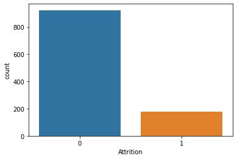

```python
# Our training labels and the counts of yes-no classes
sns.countplot(x=y_train['Attrition'])
y_train.head()
```

|  | Attrition |
| --- | --- |
| 458 | 0 |
| 814 | 0 |
| 1182 | 0 |
| 347 | 0 |
| 560 | 0 |

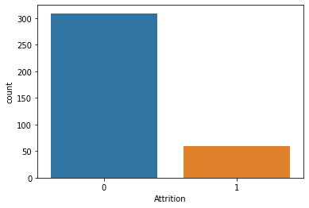

```python
# Our testing labels and the counts of yes-no classes
sns.countplot(x=y_test['Attrition'])
y_test.head()
```

### First up: DecisionTreeClassifier

A decision tree is a visualizable, interpretable, supervised classification model. Starting at the root and at each node it tries to split on a feature that is least ‘polarizing’ and gives the most information in a way that most of the observations in each side of a split fit in a unique target classification. It stops splitting when most or almost all of the observations at a node fit with a unique target classification. It does this while also attempting to minimize loss between predicted values and actual values. It is easy for a decision tree to over fit the training data, but methods such as depth-bounding, pruning, and setting a minimum number of observation at a leaf level may help reduce overfitting.

```python
from sklearn.tree import DecisionTreeClassifier
```

```python
# Obtain a decision tree classifier
dtCLF = DecisionTreeClassifier()
# Fit the classifer on the training sample
dtClF = dtCLF.fit(X_train, y_train)

# Test the classifier on the testing sample
ypredictions_dtCLF = dtCLF.predict(X_test)

# Generate performance report
report_dtCLF = metrics.classification_report(ypredictions_dtCLF, y_test)

# Print results
print(f'Tree Depth: {dtCLF.get_depth()}')
print(f'Accuracy score: {accuracy_score(y_test, ypredictions_dtCLF)}')
print(f'Classification report: \n{report_dtCLF}')
```

```
Tree Depth: 15
Accuracy score: 0.782608695652174
Classification report:
              precision    recall  f1-score   support

           0       0.86      0.88      0.87       305
           1       0.36      0.33      0.34        63

    accuracy                           0.78       368
   macro avg       0.61      0.60      0.61       368
weighted avg       0.78      0.78      0.78       368
```

Our decision tree classifier scored poorly. It seems to have poor precision and recall, especially when predicting when an employee could leave. Let's see what happens when we switch from the gini criterion to entropy. A max depth of 15 seems like the tree could grow overly complex so we will limit the maximum depth to 7. We will also limit the minimum observations or samples a leaf can have to 50.

```python
# Obtain a decision tree classifier with custom parameters
entropy_dtCLF = DecisionTreeClassifier(criterion='entropy', max_depth=7, min_samples_leaf=50)

# Fit the classifier on the training sample
entropy_dtCLF = entropy_dtCLF.fit(X_train, y_train)

# Test the classifier on the testing sample
ypredictions_entropy_dtCLF = entropy_dtCLF.predict(X_test)

# Generate performance report
report_entropy_dtCLF = metrics.classification_report(ypredictions_entropy_dtCLF, y_test)

# Print results
print(f'Tree Depth: {entropy_dtCLF.get_depth()}')
print(f'Accuracy score: {accuracy_score(y_test, ypredictions_entropy_dtCLF)}')
print(f'Classification report: \n{report_entropy_dtCLF}')
```

```
Tree Depth: 7
Accuracy score: 0.8532608695652174
Classification report:
              precision    recall  f1-score   support

           0       0.98      0.87      0.92       349
           1       0.20      0.63      0.31        19

    accuracy                           0.85       368
   macro avg       0.59      0.75      0.61       368
weighted avg       0.94      0.85      0.89       368
```

We can see that we acheived a decent improvement. However the model seems to be performing poorly on recall and especially precision when predicting that an employee will leave. Let's checkout what the model found to be the importances of the features.

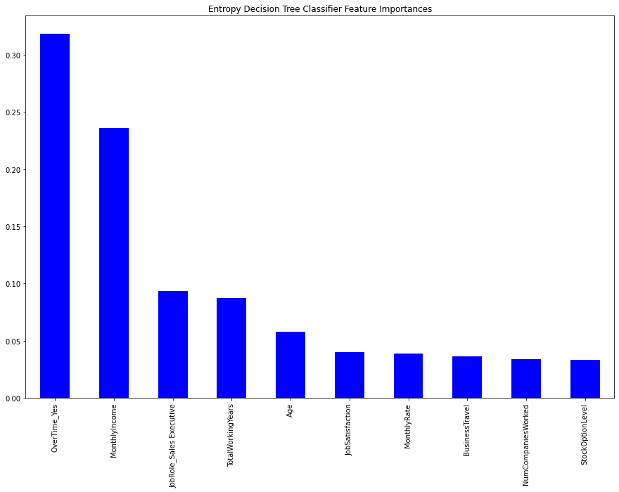

```python
topten = pd.Series(entropy_dtCLF.feature_importances_, index=X_train.columns).sort_values(ascending=False)[:10]
plt.figure(figsize=(15,10))
plot = topten.plot(kind='bar', title='Entropy Decision Tree Classifier Feature Importances', color='blue')
```

The plot above shows the features our model calculates as the top 10 most important and we will see with a visualization that it prioritizes using them to split on a node. Clearly OverTime followed by MonthlyIncome are by far the biggest indicators on attrition, but those features alone can't predict whether an employee leaves. Let's check out a visualization of the decision tree.

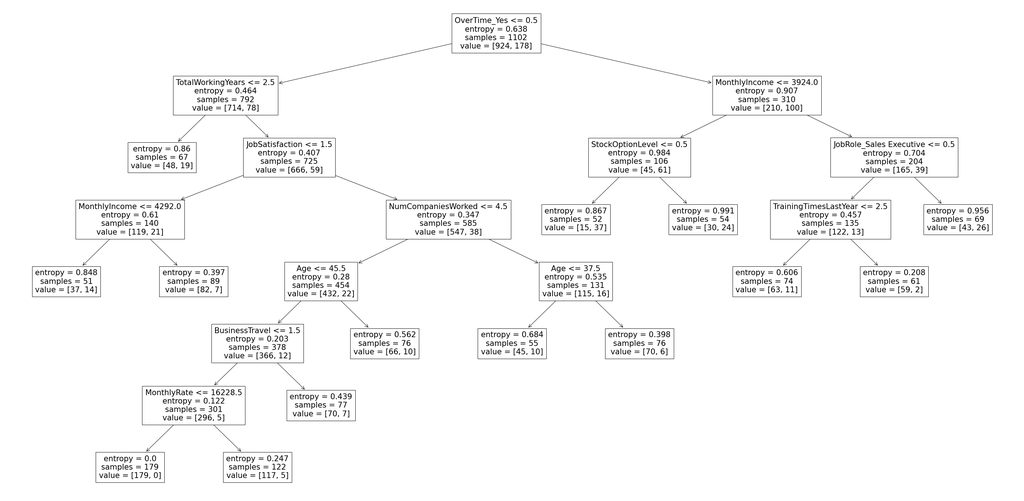

```python
from sklearn import tree
plt.figure(figsize=(50,25))
plot = tree.plot_tree(entropy_dtCLF, feature_names=entropy_dtCLF.feature_names_in_)
plt.show()
```

The image above is a visualization of how our decision tree classifies whether an employee is likely to leave the company or not. Our decision tree improved with some parameter tuning however the both the precision and recall were low especially when the model classified an employee is likely to leave. To be fair this dataset is just s snapshot and that employee could have left after the snapshot. However we want to see if we can find a model that can improve on at least one of these metrics.

Precision ratio: (The number of employees the model correctly classifies as likely to leave) **TO** (the total number of employees the model claims are likely to leave).

Recall ratio: (The number of employees the model correctly classifies as likely to leave) **TO** (the total number of employees that actually leave).

It would be ideal to improve both precision and recall drastically, but usually we can tune for one at a time. We did improve our recall and thus our overall score. However, it seems like the model is quick to classify an employee is likely to leave. The upside is that of those employees the model classifies as likely to leave, a majority of them do leave. Let's see if a different model can provide improved predictions.

### Next up: RandomForestClassifier

A random forest is a large ensemble of decision trees that vote their respective classifications on a particular observation. The trees are built with various samples (with replacement) of the data in a way that the trees are not correlated and bias is reduced. The trees will all classify the same observation then vote their result, and the majority vote in the forest wins. The hope is that forest of trees outperform any individual tree.

```python
from sklearn.ensemble import RandomForestClassifier
```

```python
# Obtain an instance of a random forest classifier
rfCLF = RandomForestClassifier(n_estimators=500, criterion='entropy')

# Fit the classifier on the training sample
rfCLF.fit(X_train, y_train['Attrition'])

# Test the classifier on the testing sample
ypredictions_rfCLF = rfCLF.predict(X_test)

# Generate performance report
report_rfCLF = metrics.classification_report(ypredictions_rfCLF, y_test)

# Print results
print(f'Accuracy score: {accuracy_score(y_test, ypredictions_rfCLF)}')
print(f'Classification report: \n{report_rfCLF}')
```

```
Accuracy score: 0.8586956521739131
Classification report:
              precision    recall  f1-score   support

           0       0.98      0.87      0.92       351
           1       0.20      0.71      0.32        17

    accuracy                           0.86       368
   macro avg       0.59      0.79      0.62       368
weighted avg       0.95      0.86      0.89       368
```

Recall performance has improved with the random forest classifier while precision performance remains low. The overall score has only a slight improvement. We did not bound the depth of the decision trees within the ensemble because having an ensemble in the first place would help cancel out the bias from overfitting an individual tree does on its sample. However we kept the criterion the same since entropy can have a slightly higher accuracy despite being slower than gini. Let's see the feature importances as calculated by the random forest.

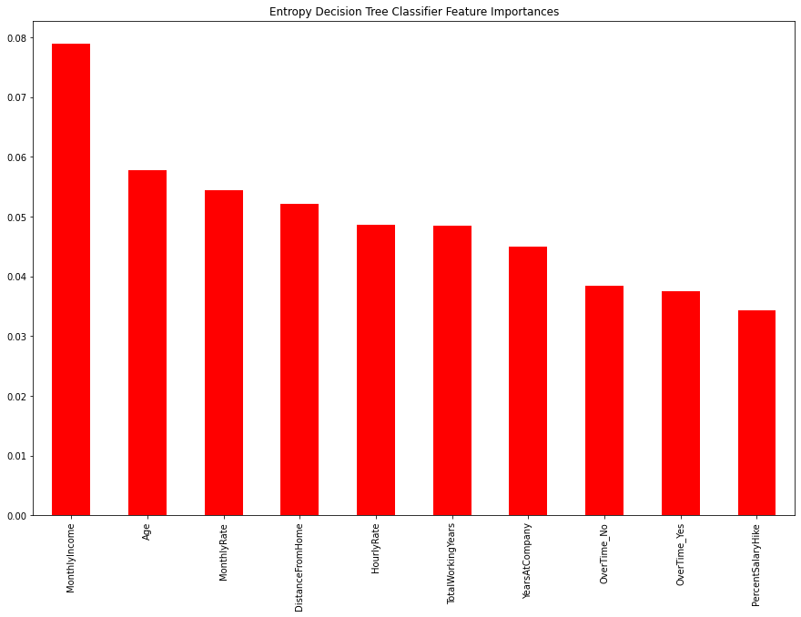

```python
topten = pd.Series(rfCLF.feature_importances_, index=X_train.columns).sort_values(ascending=False)[:10]
plt.figure(figsize=(15,10))
plot = topten.plot(kind='bar', title='Entropy Decision Tree Classifier Feature Importances', color='red')
```

The plot above shows the top 10 important features as calcualted by the random forest ensemble. Some usual suspects are still present, but there are also new features in the mix. Interestingly, the order of feature importance is different. OverTime has the highest correlation with Attrition in our previous plots and according to the DecisionTreeClassifier. However, MonthlyIncome is the most important here, and OverTime is further down the list.

### Bonus round: LogisticRegresssion

According to sklearn LogisticRegression is also a classifier model despite the regression name. Is is a maximum-entropy classifier that can fit binary classification. We will use the `lbfgs` solver because it is good for small datasets and it is robust.

```python
from sklearn.linear_model import LogisticRegression

# Obtain an instance of Logistic regressor (classifier)
logregCLF = LogisticRegression(solver='lbfgs', max_iter=10000)

# Train the classifier on the trainig sample
logregCLF.fit(X=X_train, y=y_train['Attrition'])

# Test the model on the testing sample
yprediction_logregCLF = logregCLF.predict(X_test)

# Generate performance report
report_logregCLF = metrics.classification_report(yprediction_logregCLF, y_test)

# Print results
print(f'Accuracy score: {accuracy_score(y_test, yprediction_logregCLF)}')
print(f'Classification report: \n{report_logregCLF}')
```

```
Accuracy score: 0.8913043478260869
Classification report:
              precision    recall  f1-score   support

           0       0.98      0.90      0.94       335
           1       0.44      0.79      0.57        33

    accuracy                           0.89       368
   macro avg       0.71      0.84      0.75       368
weighted avg       0.93      0.89      0.90       368
```

LogisticRegression predicts when an employee is **not likely** to leave with high precision and recall. It also improves its precision on employees that classifies as **likely** to leave while maintaining a relatively similar recall performance.

## Conclusion

In predicting the attrition of employees, there is no one attribute whose values can tell us whether an employee is going to leave the company or not. It turns out that there are multiple attributes that are needed to predict attrition at least somewhat accurately. This is reflected by the charts presented in the exploratory data analysis section of this project, where multiple correlation relationships were needed to explain the possible trends that affected the attrition rate. This result was expected because jobs are very important to people, and so it would make sense that multiple aspects of a company would drive people to leave, not just one or two.

From what relationships we could identify as being the most significant in determining the attrition rate, we found that overtime, monthly income, and total years worked at the company had the most effect on attrition. More specifically, people who had less total years working at the company, especially within 1 year, whose monthly income was low, and who worked overtime were the most likely to leave the company.

For our machine learning model we were not able to break the 90% accuracy barrier with our three models: DecisionTree, RandomForest, and LogisticRegression. The most accurate model we used is the LogisticRegression with 89% accuracy score followed by RandomForest and DecisionTreeClassifer that both hovered around 86%. One metric that all three models performed poorly on is precision on positive classifications. It seems that the models more often incorrectly attempted to classify employees as likely to leave. One reason this maybe is because the proportion of the positive class is way smaller than the proportion of the negative class. It understandable then that since there are way fewer positive observations than there are negative observations that the models could yield many false positives. One possible remedy to this is to train the models on much larger dataset, however we do not have access to a larger dataset from this company.